# A Study in Factors on Musical Performance

Author

Madison Loutensock

# Introduction

Throughout my life, I have had many experiences with private music lessons. I took private piano lessons for about 8 years and, recently, I have been working as a private piano teacher for the last 4 years. Therefore, I am very interested in analyzing what makes a lesson the most effective, so that I can be the an effective teacher.

My main research question is: “What factors in a private music lesson will help increase a student’s performance?”

The sub-questions I will be focusing on are: Do students who have a longer duration of lessons tend to get better performance scores than others? Do students whose lessons focus on playing the instrument(practicality) tend to get better performance scores than those who focus on the theory? Does the age of the student affect their performance score?

# Design the Study

For this analysis, I will be using data taken from a study done on Music Education Performance, where a variety of possible factors were tested, as well as an overall performance score. I will be looking at both quantitative and categorical data and I expect to do at least one t.test and an ANOVA test. The population for this analysis is all people who take private music lessons.

Response Variable: Performance Score

Possible Explanatory Variables:  
1.Duration - Quantitative  
2.Lesson Type - Categorical  
3.Age - Categorical

# Collect the Data

When I was first looking for data to analyze, my research question was “Does taking music lessons increase general education performance?” However, as I was looking into different data sets, I was drawn to this one about what affects musical performance. Due to the focus of the data being different from my original question, I had to adjust what I planned to research. I found the data through the website Kaggle, and the data was gathered in December of 2024.

# Describe/Summarize the Data

```r
#read in libraries and dataset
library(tidyverse)
library(mosaic)
library(rio)
library(ggplot2)
library(readr)
library(car)
setwd("C:/Users/madl1/OneDrive/Desktop/Student_Work/6-Semester_Project")

music <- read_csv("music_education_dataset.csv")
view(music)

#clean up data
unique(music$Lesson_Type)
```

```
[1] "Theory"    "Practical"
```

```r
unique(music$Age)
```

```
[1] 12 11 13 16 15 14 10 17
```

```r
clean_music <- music %>%
  filter(Performance_Score >= 60,
         Performance_Score <= 100) %>%
  select(Performance_Score, Duration, Lesson_Type, Age, Stress_Level)

view(clean_music)
```

# Make Inference

### Analyzing the linear relationship between performance score and duration of play time in lessons

$$H_0: \beta = 0$$

$$H_a:\beta > 0$$
$$\alpha = 0.05$$

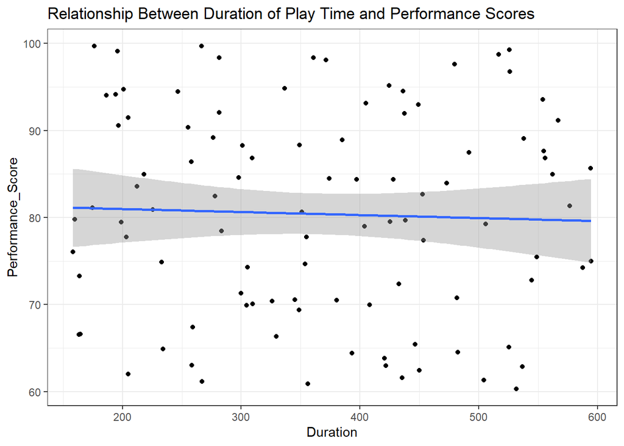

```r
#explore and visualize data
ggplot(clean_music, aes(y = Performance_Score, x = Duration)) +
  geom_point() +
  geom_smooth(method = "lm") +
  labs(
    title = "Relationship Between Duration of Play Time and Performance Scores"
  ) +
  theme_bw()
```

The scatterplot seems to have points all over the graph. There is a slight linear relationship but it is a very weak negative one.

```r
#correlation coefficient
cor(clean_music$Performance_Score ~ clean_music$Duration)
```

```
[1] -0.03752925
```

```r
#testing for linear regression
lm_music <- lm(clean_music$Performance_Score ~ clean_music$Duration)
summary(lm_music)
```

```
Call:
lm(formula = clean_music$Performance_Score ~ clean_music$Duration)

Residuals:
     Min       1Q   Median       3Q      Max
-19.6041 -10.0096   0.0233   9.5801  19.4098

Coefficients:
                      Estimate Std. Error t value Pr(>|t|)
(Intercept)          81.679254   3.608076  22.638   <2e-16 ***
clean_music$Duration -0.003459   0.009303  -0.372    0.711
---
Signif. codes:  0 '***' 0.001 '**' 0.01 '*' 0.05 '.' 0.1 ' ' 1

Residual standard error: 11.8 on 98 degrees of freedom
Multiple R-squared:  0.001408,  Adjusted R-squared:  -0.008781
F-statistic: 0.1382 on 1 and 98 DF,  p-value: 0.7109
```

**Correlation Coefficient(r)**: -0.038, which is a very weak negative relationship  
**Slope**: -0.003459  
**Intercept**: 81.679254  
**p-value**: 0.711  
**Interpretation**: The p-value is not less than alpha(0.05), therefore I fail to reject the null hypothesis. I do not have sufficient evidence to suggest that the duration of play time in lessons has an effect on a student’s performance score.

```r
#confidence interval
confint(lm_music, level = 0.95)
```

```
                           2.5 %      97.5 %
(Intercept)          74.51914482 88.83936395
clean_music$Duration -0.02191961  0.01500241
```

**Confidence Interval**: I am 95% confident that the true slope of the relationship between duration and performance score is between -0.022 and 0.015. For every one second more play time in a lesson, a student’s performance score changes by between -0.022 and 0.015, therefore there is little to no difference between scores in relation to the duration of play time in lessons.

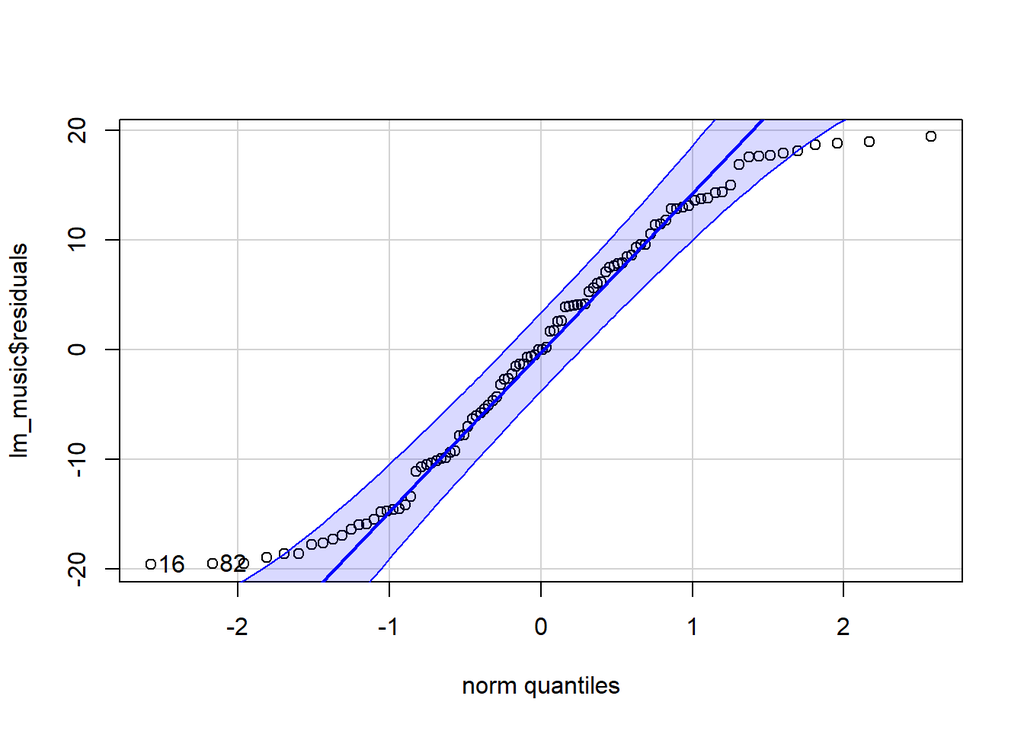

```
[1] 16 82
```

```r
#check requirements

#residuals
qqPlot(lm_music$residuals)
```

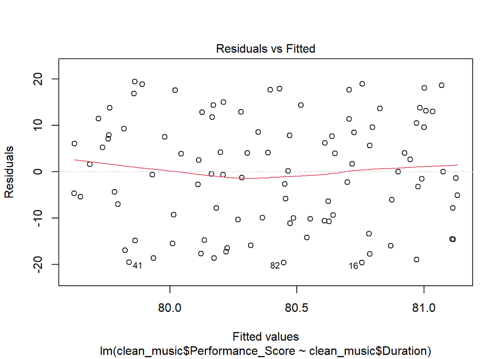

```r
#variance
plot(lm_music, which = 1)
```

**Residuals**: The residuals are normal  
**Variance**: The variance is constant  
**Trust p-value**: Yes, I can trust my p-value

### Analyzing the relationship between Lesson Type and Performance Score through independent t.test

$$H_0: \mu_{Practical} = \mu_{Theory}$$

$$H_a:\mu_{P} > \mu_{T}$$
$$\alpha = 0.05$$

```r
# explore and visualize data
favstats(clean_music$Performance_Score ~ clean_music$Lesson_Type)
```

```
  clean_music$Lesson_Type      min       Q1   median       Q3      max     mean
1               Practical 60.32214 70.42106 79.33088 91.90368 99.71868 80.75567
2                  Theory 60.90163 70.45786 81.01049 88.01304 98.35884 80.09406
        sd  n missing
1 12.64735 48       0
2 10.97366 52       0
```

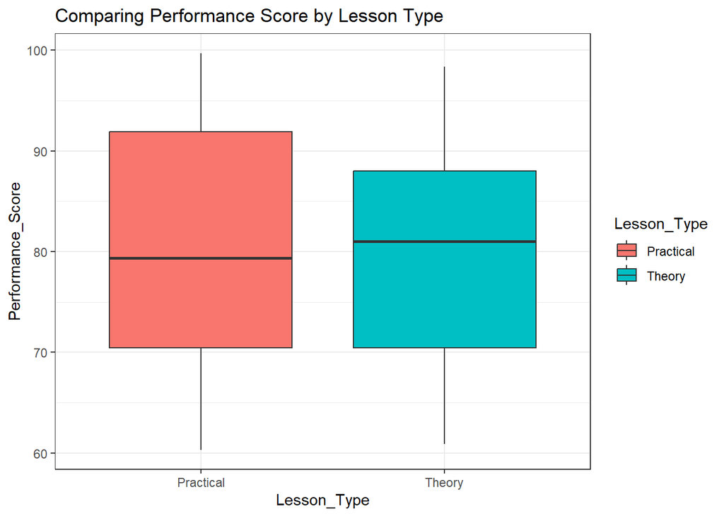

```r
ggplot(clean_music, aes(y = Performance_Score, x = Lesson_Type, fill = Lesson_Type)) +
  geom_boxplot() +
  theme_bw() +
  labs( title = "Comparing Performance Score by Lesson Type")
```

Looking at the boxplot and summary statistics, the theory focused lessons have a slightly larger median of performance scores than practical lessons. However, the variability of performance scores for practical lessons is larger, which may even it out.

```r
#t.test
t.test(clean_music$Performance_Score ~ clean_music$Lesson_Type, alternative = "greater")
```

```
    Welch Two Sample t-test

data:  clean_music$Performance_Score by clean_music$Lesson_Type
t = 0.27839, df = 93.437, p-value = 0.3907
alternative hypothesis: true difference in means between group Practical and group Theory is greater than 0
95 percent confidence interval:
 -3.286678       Inf
sample estimates:
mean in group Practical    mean in group Theory
               80.75567                80.09406
```

**t**: 0.27839  
**df**: 93.437  
**p-value**:0.3907  
**Interpretation**: The p-value is not less than alpha, therefore I fail to reject the null hypothesis. I do not have sufficient evidence to suggest that students who take practical lessons get higher performance scores than those who take theory lessons.

```r
#confidence interval
t.test(clean_music$Performance_Score ~ clean_music$Lesson_Type, conf.level = 0.95)$conf.int
```

```
[1] -4.057536  5.380770
attr(,"conf.level")
[1] 0.95
```

**Confidence Interval**: I am 95% confident that the true difference in performance scores of students who take practical lessons is between 4.058 less points and 5.381 more points than those who take theory lessons.

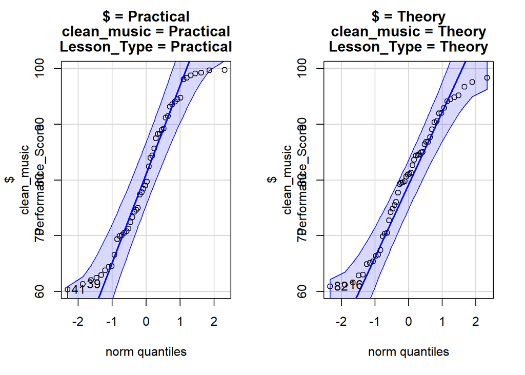

```r
#check for normality
qqPlot(clean_music$Performance_Score ~ clean_music$Lesson_Type)
```

**Normality**: The data is normal  
**Trust p-value**: Yes, I can trust my p-value

### Analyzing the relationship between performance score and age of the student through ANOVA

$$H_o: \mu_{10} = \mu_{11} = \mu_{12} = \mu_{13} = \mu_{14} = \mu_{15} = \mu_{16} = \mu_{17}$$
$$H_a: \text{at least one age is different from the others}$$
$$\alpha = 0.05$$

```r
#explore and visualize data
favstats(clean_music$Performance_Score ~ clean_music$Age)
```

```
  clean_music$Age      min       Q1   median       Q3      max     mean
1              10 62.45821 75.00191 78.73816 83.88848 91.95686 79.15447
2              11 60.32214 67.64399 81.09731 90.57224 98.34762 79.77874
3              12 66.59983 78.21241 88.26834 93.86581 99.71868 86.05738
4              13 69.36536 74.27390 79.27591 86.82123 99.09256 81.83812
5              14 62.02598 80.92366 89.08685 90.37172 99.27092 85.47973
6              15 60.90163 68.17329 80.63383 91.77526 95.18108 79.27251
7              16 61.57539 64.44112 76.94194 90.07525 98.73710 77.54758
8              17 62.88485 66.49549 70.31074 85.61312 96.74020 76.23158
         sd  n missing
1  7.616312 14       0
2 14.167100 11       0
3 11.281281 12       0
4 10.538332 13       0
5 11.088852  9       0
6 12.672438 15       0
7 13.799823 14       0
8 11.513882 12       0
```

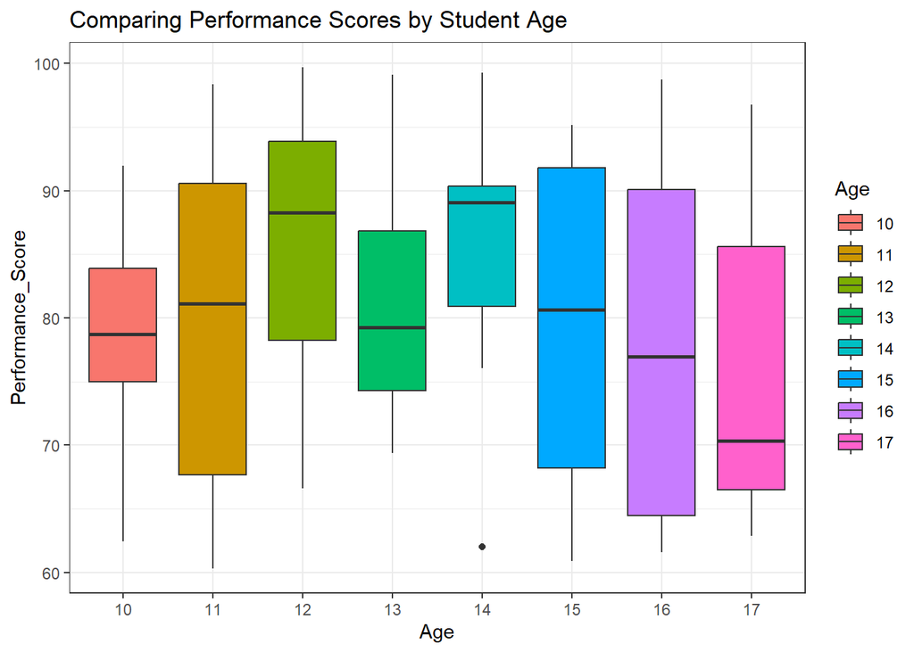

```r
category_order <- c("10", "11", "12", "13", "14", "15", "16", "17")

ggplot(clean_music, aes(y = Performance_Score, x =factor(Age, levels = category_order), fill = factor(Age, levels = category_order))) +
  geom_boxplot() +
  theme_bw() +
  labs(
    x = "Age",
    title = "Comparing Performance Scores by Student Age",
    fill = "Age")
```

Looking at the summary statistics and the boxplot, age 17’s median does seem to be lower than the others.

```r
#anova test
music_aov <- aov(clean_music$Performance_Score ~ clean_music$Age)
summary(music_aov)
```

```
                Df Sum Sq Mean Sq F value Pr(>F)
clean_music$Age  1    178   178.3   1.295  0.258
Residuals       98  13492   137.7
```

**f**: 1.295  
**df**: 1  
**p-value**: 0.258  
**Interpretation**: The p-value is not less than alpha(0.05), therefore I fail to reject the null hypothesis. I do not have sufficient evidence to suggest that the age of the student has a significant affect on their performance score.

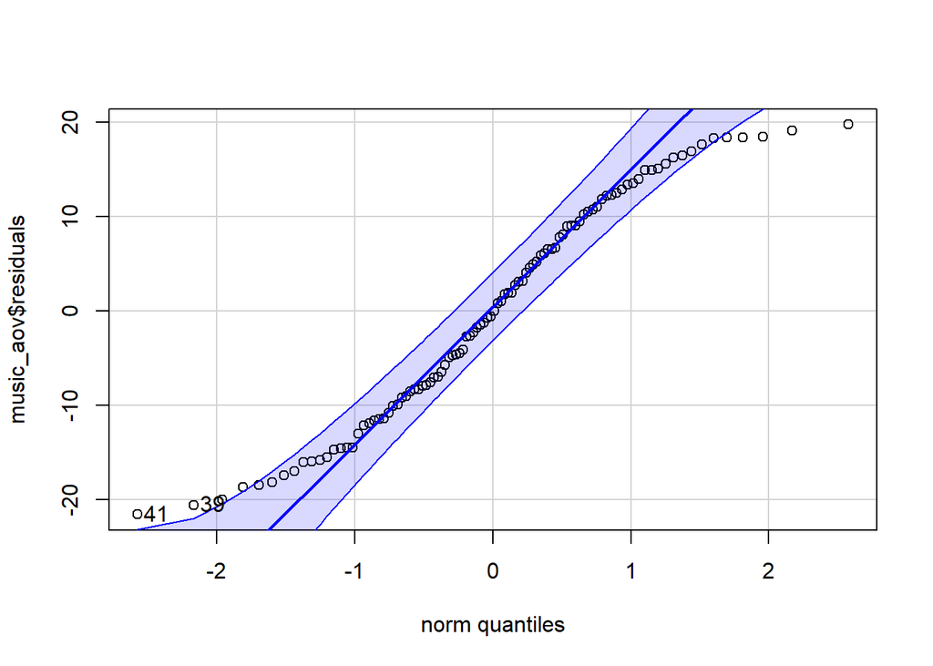

```
[1] 41 39
```

```r
#check requirements

#residuals
qqPlot(music_aov$residuals)
```

```r
#standard deviation variability
sds <- favstats(clean_music$Performance_Score ~ clean_music$Age)$sd
max(sds) / min(sds)
```

```
[1] 1.8601
```

**Residuals**: The residuals are normal  
**SD**: The standard deviations are approximately equal  
**Trust p-value**: Yes, I can trust my p-value

# Conclusion (Take Action)

From my findings, I conclude that neither duration of play time, lesson type, nor age have a significant affect on a student’s performance score. These findings did surprise me a little, as I expected to see a relationship between at least one of them and performance score. However, my findings do imply that no matter what type of lesson a student takes, how long the lesson is, or how old they are, they can still do well in a performance. After analyzing this data, I would be interested in doing some more studies to see what factors do affect a student’s performance score.